# Mixture Models

Lecture 36

April 27, 2026

# Class Logistics

## Changes To Grading

- No literature critique for 5850;
- Project presentations + peer reviews for everyone to help get feedback prior to report.

## Project Presentation

1. Upload recording of max 10 minute presentation to Canvas by 5/6;
2. Submit peer reviews to Canvas by 5/8 (will be auto-assigned).
3. You will be graded on the quality and constructiveness of the peer reviews you provide (templates on website), but not the reviews you receive.

# Bimodel Distributions

## Mixture Models

What happens when data comes from multiple data-generating processes?

- Streamflow: drought vs. wet conditions
- Solar radiation: cloud regimes
- Precipitation: synoptic-scale weather regimes

## Example: Colorado River Streamflow

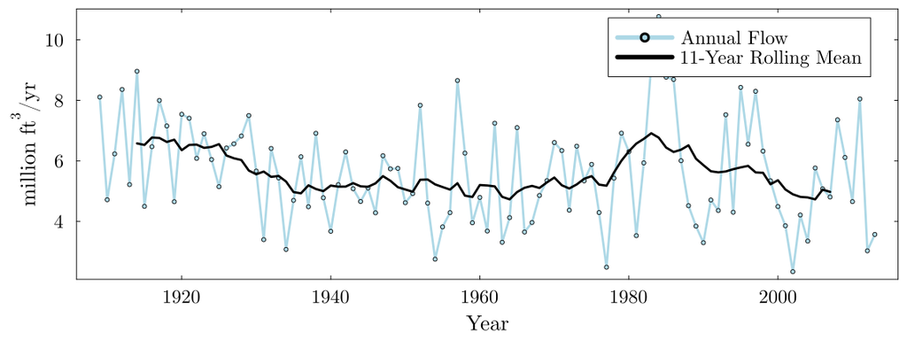

Figure 1: Streamflow data from the Upper Colorado

```julia
annual_q = CSV.read("data/streamflow/uc_historical.csv", DataFrame)
annual_q.Year = 1909:2013
annual_q.Upper_Colorado_norm = annual_q.Upper_Colorado / 1e6
p = plot(annual_q.Year, annual_q.Upper_Colorado_norm , marker=:circle, markersize=3, label="Annual Flow", color=:lightblue, ylabel=L"million ft$^3$/yr", xlabel="Year", leftmargin=10mm)
plot!(p, size=(1200, 450))

# compute rolling mean
ll = 11
roll = zeros(nrow(annual_q) - ll)
for i = 1:(nrow(annual_q) - ll)
    wind = i:(i+ll-1)
    roll[i] = mean(annual_q[wind, :Upper_Colorado_norm])
end
# plot rolling mean
plot!(p, annual_q[Int(floor((ll+1)/2)):(end-Int(floor((ll+1)/2))), :Year], roll, color=:black, label="11-Year Rolling Mean")
```

## Defining “Drought”

Ault et al. (2014): Define a decadal “drought” as when the 11-year mean falls below 1/2 the standard deviation from the overall mean.

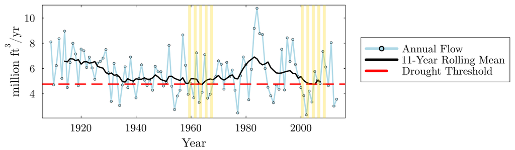

Figure 2: Droughts in the Upper Colorado

## Mixture of Two Distributions

“Droughts” vs “Normal” Streamflow can be thought of as two different distributions occurring with different probabilities.

This is a **mixture model**:

$$\begin{aligned}
Z &\sim \text{Mult}(\pi_1, \ldots, \pi_K) \\
Y | Z &\sim \mathcal{D}_Z = f_Z
\end{aligned}$$

Very common to use Gaussians for $\mathcal{D}_k$ but this isn’t necessary.

## Mixture Models and Clustering

Mixture models are common for **model-based clustering** (a parametric alternative to *e.g*. $k$-means).

This is:

- Good! A mixture model is predictive, might explain the data, and can be checked with *e.g.* cross-validation.
- Bad! Highly sensitive to specification of distributions.

## Example Based On Ault (2014) Definition

```julia
annual_q.Upper_Colorado_log = log.(annual_q.Upper_Colorado)
histogram(annual_q.Upper_Colorado_log, xlabel=L"log-ft$^3$/yr", ylabel="PDF", norm=:pdf, fillcolor=:gray, alpha=0.5, label="Observations")
all_dist = fit(Normal, annual_q.Upper_Colorado_log)
plot!(all_dist, color=:black, label="Combined Distribution")
dry_flow = annual_q[dry_yrs, :Upper_Colorado_log]
wet_flow = annual_q[.!(dry_yrs), :Upper_Colorado_log]
dry_dist = fit(Normal, dry_flow)
wet_dist = fit(Normal, wet_flow)
plot!(dry_dist, color=:red, label="Dry Distribution")
plot!(wet_dist, color=:blue, label="Wet Distribution")
plot!(size=(1200, 450), legend=:outerright)
```

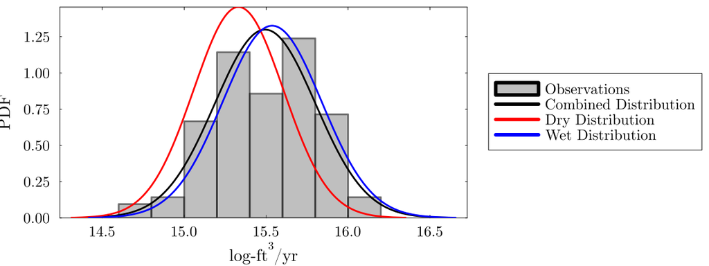

Figure 3: Mixture Fits for Drought Data

## Fitting Mixture Models

The likelihood of a Gaussian mixture model:
$$L(\theta | \mathbf{y}) = \prod_{i=1}^n \sum_{k=1}^K \pi_k N(y_i; \mu_k, \sigma_k^2)$$

and so the log-likelihood:
$$l(\theta | \mathbf{y}) = \sum_{i=1}^n \log \left(\sum_{k=1}^K \pi_k N(y_i; \mu_k, \sigma_k^2)\right).$$

## Fitting Mixture Models

$$\begin{aligned}
\frac{\partial l}{\partial \theta_k} &= \sum_{i=1}^n \frac{1}{\sum_{j=1}^K \pi_j f_j(x_i; \theta)} \pi_k \frac{\partial f_k(y_i; \theta)}{\partial \theta_k} \\
&= \sum_{i=1}^n \frac{\pi_k f_k(x_i; \theta)}{\sum_{j=1}^K \pi_j f_j(x_i; \theta)} \frac{1}{f_j(x_i, \theta)} \frac{\partial f_k(y_i; \theta)}{\partial \theta_k} \\
&= \sum_{i=1}^n \frac{\pi_k f_k(x_i; \theta)}{\sum_{j=1}^K \pi_j f_j(x_i; \theta)} \frac{\partial \log f_j(x_i; \theta)}{\partial \theta_k}
\end{aligned}$$

## The Problem…

Maximizing this log-likelihood is a **weighted** likelihood maximization based on the component membership probabilities

$$w_{ik} = \frac{\pi_k f_k(x_i; \theta)}{\sum_{j=1}^K \pi_j f_k(x_i; \theta)} = p(Z_i = j | X_i = x_i; \theta).$$

But to calculate $w_{ik}$ we need to know the parameters…

## The E-M Algorithm

The **E-M (Expectation-Maximization) Algorithm** is an iterative approach to solving this problem:

0. Initialize the parameters for the mixture components, call this $\theta^{(0)}$.

## The E-M Algorithm

The **E-M (Expectation-Maximization) Algorithm** is an iterative approach to solving this problem:

1. **E-step**: Find the expected complete data log-likelihood
   $$\begin{aligned}
   Q(\theta, \theta^(t)) &= E_{Z | Y, \theta^{(t)}}\left[\log p(Y, Z| \theta)\right] \\
   &= \sum_{i=1}^n \sum_{k=1}^K p(Z_i = k | y_i, \theta^{(t)}) \log p(y_i | Z_i = k, \theta).
   \end{aligned}$$

## The E-M Algorithm

The **E-M (Expectation-Maximization) Algorithm** is an iterative approach to solving this problem:

2. **M-step**: Find new parameter values by maximizing $Q$:
   $$\theta^{(t+1)} = \arg\max_\theta Q(\theta, \theta^{(t)}).$$

## The E-M Algorithm

The **E-M (Expectation-Maximization) Algorithm** is an iterative approach to solving this problem:

3. Check for convergence of $Q$ (usually by checking if log-likelihood has stabilized within some threshold).

## The E-Step

Note

$$\begin{aligned}
p(Z_i = k | y_i, \theta^{(t)}) &= \frac{p(Z_i = k, Y_i = y_i | \theta^{(t)}}{p(Y_i = y_i | \theta^{(t)})} \\
&= \frac{p(Y_i = y_i | Z_i = k, \theta^{(t)})p(Z_i = k | \theta^{(t)})}{\sum_{j=1}^K p(Y_i = y_i | Z_i = j, \theta^{(t)})p(Z_i = j | \theta^{(t)})} \\
&= \frac{\pi_k^{(t)}p(y_i | Z_i = k, \theta^{(t)})}{\sum_{j=1}^K \pi_j^{(t)}p(y_i | Z_i = j, \theta^{(t)})}
\end{aligned}$$

Call the outputs of this calculation $w_k^i$.

## The M-Step

In the Gaussian case, can explicitly calculate the updates (otherwise use numerical optimization on the E-Step output).

## The M-Step

Define $N_k = \sum_{i=1}^n w_k^i$, and then:

$$\begin{aligned}
\pi_k^{(t+1)} &= \frac{N_k}{N} \\
\mu_k^{(t+1)} &= \frac{1}{N_k} \sum_{i=1}^n w_k^i x_i \\
(\sigma_k^2)^{(t+1)} &= \frac{1}{N_k} \sum_{i=1}^n (x_i - \mu_k^{(t+1)})^2 w_k^i
\end{aligned}$$

## The E-Step

```julia
function e_step(y, p, mu, sigma)
    N = length(y)
    K = length(p)
    w = zeros(N, K)
    # compute weights for each point
    for k in 1:K
        w[:, k] = p[k] * pdf.(Normal(mu[k], sigma[k]), y)
    end
    w_tot = sum(w, dims=2) # normalize weights
    return w ./ w_tot
end
```

## The M-Step

```julia
function m_step(y, w)
    N = length(y)
    K = size(w, 2)
    Nk = sum(w, dims=1) # soft count of mixture membership

    # update coefficients
    p = Nk / N
    mu = sum(w .* y; dims=1) ./ Nk
    sigma = sqrt.(sum(w .* (y .- mu).^2; dims=1) ./ Nk)
    return (p, mu, sigma)
end
```

## The Full Algorithm

```julia
# compute log-likelihood for tracking
function log_likelihood(y, p, mu, sigma)
    N = length(y)
    K = length(p)
    ll_comp = zeros(N, K)
    for k = 1:K
        ll_comp[:, k] = p[k] * pdf.(Normal(mu[k], sigma[k]), y)
    end
    ll = sum(log.(sum(ll_comp, dims=2)))
    return ll
end

function em_algorithm(y, p_init, mu_init, sigma_init; max_iter = 300, thresh=1e-4)
    N = length(y)
    K = length(p_init)

    # initialize storage and add initial guesses
    p = zeros(max_iter + 1, K)
    p[1, :] = p_init
    mu = zeros(max_iter + 1, K)
    mu[1, :] = mu_init
    sigma = zeros(max_iter + 1, K)
    sigma[1, :] = sigma_init

    # compute initial log-likelihood
    ll = zeros(max_iter + 1)
    ll[1] = log_likelihood(y, p[1, :], mu[1, :], sigma[1, :])

    iter = 1
    for t = 1:max_iter
        w = e_step(y, p[t, :], mu[t, :], sigma[t, :])
        p[t+1, :], mu[t+1, :], sigma[t+1, :] = m_step(y, w)
        ll[t+1] = log_likelihood(y, p[t+1, :], mu[t+1, :], sigma[t+1, :])
        if abs(ll[t+1] - ll[t]) < thresh
            break
        end
        iter += 1
    end

    return (p[1:iter+1, :], mu[1:iter+1, :], sigma[1:iter+1, :], ll[1:iter+1, :])
end
```

## E-M Algorithm Convergence

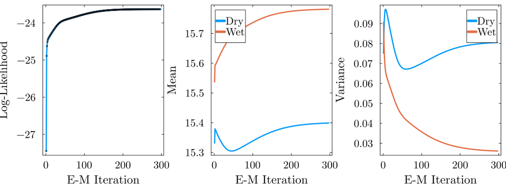

```julia
mu_init = zeros(2)
sigma_init = zeros(2)
mu_init[1] = dry_dist.μ
sigma_init[1] = dry_dist.σ
mu_init[2] = wet_dist.μ
sigma_init[2] = wet_dist.σ
p_init = [0.5, 0.5]

p, mu, sigma, ll = em_algorithm(annual_q.Upper_Colorado_log, p_init, mu_init, sigma_init, max_iter = 1000, thresh=1e-5)

p1 = plot(ll, marker=:circle, markersize=2, xlabel="E-M Iteration", ylabel="Log-Likelihood", label=false)
p2 = plot(mu, xlabel="E-M Iteration", ylabel="Mean", label=["Dry" "Wet"])
p3 = plot(sigma.^2, xlabel="E-M Iteration", ylabel="Variance", label=["Dry" "Wet"])
plot(p1, p2, p3, layout=(1, 3), size=(1200, 450))
```

## Example of E-M Algorithm

```julia
histogram(annual_q.Upper_Colorado_log, xlabel=L"log-ft$^3$/yr", ylabel="PDF", norm=:pdf, fillcolor=:gray, alpha=0.5, label="Observations", legend=:outerright)
plot!(dry_dist, color=:red, linestyle=:dash, label="Dry (Ault)", xlabel=L"log-ft$^3$/yr", ylabel="PDF")
plot!(wet_dist, color=:blue, linestyle=:dash, label="Wet (Ault)")
plot!(Normal(mu[end, 1], sigma[end, 1]), color=:red, label="Dry (E-M)")
plot!(Normal(mu[end, 2], sigma[end, 2]), color=:blue, label="Wet (E-M)")
```

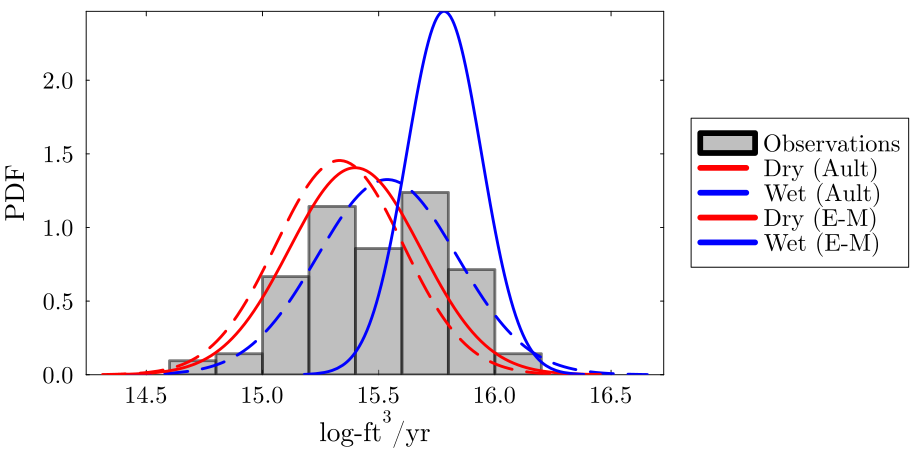

## Fitted Mixture Fit

```julia
mix_dist = MixtureModel(Normal, [(mu[end, 1], sigma[end, 1]), (mu[end, 2], sigma[end, 2])], p[end, :])
mix_samp = rand(mix_dist, 10_000)
qqplot(annual_q.Upper_Colorado_log, mix_samp, xlabel="Observations", ylabel="Mixture Model")
```

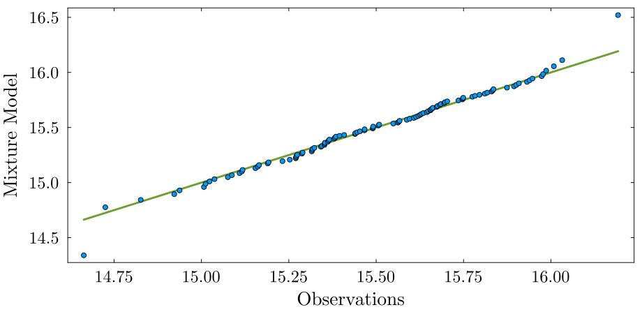

Figure 5: E-M Fit

## Probabilities of Observations

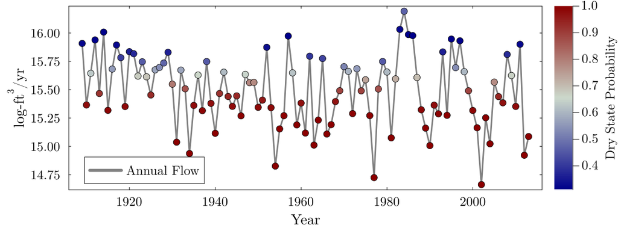

Figure 6: E-M Probabilities

```julia
# compute component probabilities
N = nrow(annual_q)
K = 2 # number of mixture components
ll_comp = zeros(N, K)
for k = 1:K
    ll_comp[:, k] = p[end, k] * pdf.(Normal(mu[end, k], sigma[end, k]), annual_q.Upper_Colorado_log)
end
ll = ll_comp ./ sum(ll_comp, dims=2) # normalize to get probabilities
annual_q.dry_prob = ll[:, 1]
p = plot(annual_q.Year, annual_q.Upper_Colorado_log, label="Annual Flow", color=:gray, ylabel=L"log-ft$^3$/yr", xlabel="Year", leftmargin=10mm)
scatter!(p, annual_q.Year, annual_q.Upper_Colorado_log, markersize=7, marker_z = annual_q.dry_prob, c = cgrad(:bluesreds), colorbar_title = "Dry State Probability", colorbar_titlefontsize=16, label=false)
plot!(size=(1200, 450))
```

## What Don’t Mixture Models Tell Us

Mixture models are useful for clustering or generating bimodel distributions. But they are limited for understanding intertemporal dynamics.

For example: we don’t see the **persistence** of wet/dry states, with frequent switches between them. **Is this reasonable**?

To address this, we’ll need a generative model for state switching: a **Hidden Markov Model**.

# Markov Chains

## Hidden Markov Models

Instead, we might want to model the process that gives **rise** to a mixture distribution.

One way to do this for time series is with a **Hidden Markov Model** where the generative model at time $t$ probability model “switches” probabilistically based on a **Markov chain**.

## What Is A Markov Chain?

Consider a stochastic process $\{X_t\}_{t \in \mathcal{T}}$, where

- $X_t \in \mathcal{S}$ is the state at time $t$, and
- $\mathcal{T}$ is a time-index set (can be discrete or continuous)
- $\mathbb{P}(s_i \to s_j) = p_{ij}$.

[figure not shown]

Markov State Space

## Markovian Property

This stochastic process is a **Markov chain** if it satisfies the **Markovian (or memoryless) property**:
$$\begin{align*}
\mathbb{P}(X_{T+1} = s_i &| X_1=x_1, \ldots, X_T=x_T) = \\ &\qquad\mathbb{P}(X_{T+1} = s_i| X_T=x_T)
\end{align*}$$

## Example: “Drunkard’s Walk”

[figure not shown]

- How can we model the *unconditional* probability $\mathbb{P}(X_T = s_i)$?
- How about the *conditional* probability $\mathbb{P}(X_T = s_i | X_{T-1} = x_{T-1})$?

## Example: Weather

Suppose the weather can be foggy, sunny, or rainy.

Based on past experience, we know that:

1. There are never two sunny days in a row;
2. Even chance of two foggy or two rainy days in a row;
3. A sunny day occurs 1/4 of the time after a foggy or rainy day.

## Aside: Higher Order Markov Chains

Suppose that today’s weather depends on the prior *two* days.

1. Can we write this as a Markov chain?
2. What are the states?

## Weather Transition Matrix

We can summarize these probabilities in a **transition matrix** $P$:
$$P =
\begin{array}{cc}
\begin{array}{ccc}
\phantom{i}\color{red}{F}\phantom{i} & \phantom{i}\color{red}{S}\phantom{i} & \phantom{i}\color{red}{R}\phantom{i}
\end{array}
\\
\begin{pmatrix}
1/2 & 1/4 & 1/4 \\
1/2 & 0 & 1/2 \\
1/4 & 1/4 & 1/2
\end{pmatrix}
&
\begin{array}{ccc}
\color{red}F \\ \color{red}S \\ \color{red}R
\end{array}
\end{array}$$

## Weather Example: State Probabilities

Denote by $\lambda^t$ a probability distribution over the states at time $t$.

Then $\lambda^t = \lambda^{t-1}P$:

$$\begin{pmatrix}\lambda^t_F & \lambda^t_S & \lambda^t_R \end{pmatrix} =
\begin{pmatrix}\lambda^{t-1}_F & \lambda^{t-1}_S & \lambda^{t-1}_R \end{pmatrix}
\begin{pmatrix}
1/2 & 1/4 & 1/4 \\
1/2 & 0 & 1/2 \\
1/4 & 1/4 & 1/2
\end{pmatrix}$$

## Multi-Transition Probabilities

Notice that
$$\lambda^{t+i} = \lambda^t P^i,$$
so multiple transition probabilities are $P$-exponentials.

## Long Run Probabilities

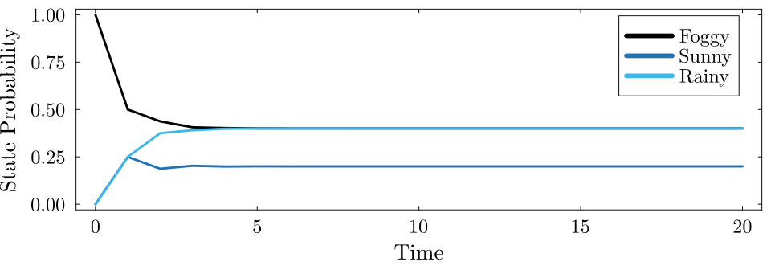

Figure 7: State probabilities for the weather examples.

```julia
current = [1.0, 0.0, 0.0]
P = [1/2 1/4 1/4
    1/2 0 1/2
    1/4 1/4 1/2]

T = 21

state_probs = zeros(T, 3)
state_probs[1,:] = current
for t=1:T-1
    state_probs[t+1, :] = state_probs[t:t, :] * P
end


p = plot(0:T-1, state_probs, label=["Foggy" "Sunny" "Rainy"], palette=:mk_8, linewidth=3)
xlabel!("Time")
ylabel!("State Probability")
plot!(p, size=(1000, 350))
```

# Key Points and Upcoming Schedule

## Key Points

- Mixture Models: produce multi-modal distributions by mixing different distributions together
- Fit mixture models using Expectation-Maximization (E-M) algorithm
- Markov chains to represent “switching” between different latent states.

## Upcoming Schedule

**Wednesday**: More on Markov chains and Hidden Markov Models

**Friday**: Quiz 6, finish HMM example

# References

## References (Scroll for Full List)

Ault, T. R., Cole, J. E., Overpeck, J. T., Pederson, G. T., & Meko, D. M. (2014). Assessing the risk of persistent drought using climate model simulations and paleoclimate data. *J. Clim.*, *27*, 7529–7549. https://doi.org/10.1175/jcli-d-12-00282.1